# Chapter 2: Statistical Modeling

This chapter deals with statistical modeling: creating a model that can plausibly explain the data. All examples are parametric but the procedures generalize for nonparametric models as well.

Estimated data are represent with hat (^) wearing Greek letters.

### Chapter Goals

1. Be able to recognize the difference between probability and statistics.
2. Fit data to probability distributions such as histograms.
3. Become familiar with maximum likelihood estimating procedure.
4. Make inferences from data which we have previous info on.

### Parameters

**λ** defines a Poisson distribution.  
**μ** is used to represent the mean of the normal distribution.  
**θ** is used to designate a generic tuple of parameters necessary to specify a probability model. In the case of the binomial distribution, θ=(n,p)

## 2.2 The difference between statistical and probabilistic models

To conduct a *probalistic analysis* we need a generative model and the paramters actual values.

In *statistical inference* we may know some of the paramters but not all of them. We must then go up from the known parameters to estimate both a probability model F (Poisson, normal, binomial) and eventually the missing parameter(s) for that model.

## 2.3 A simple example of statistical modeling

Let’s use the epitope example from Chatper 1 to construct a visual evaluation of goodness-of-fit. We will remove the outlier (the 100th data point).

Our first step is to find a fit from candidate distributions; this requires consulting graphical and quantitative goodness-of-fit plots.  
For *discrete data*, we can plot a barplot of frequencies.  
For *continuous data*, we look at the histogram.

Barplot of the epitope data.

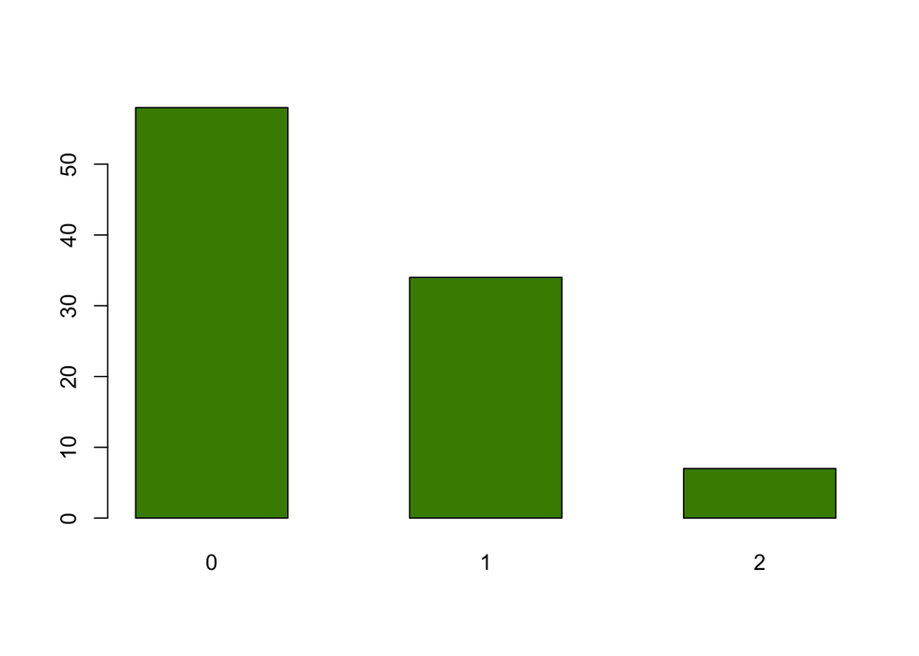

```r
load("e100.RData")
e99 = e100[-which.max(e100)]
barplot(table(e99), space = 0.8, col = "chartreuse4")
```

It is hard to decide which theoretical distribution fits the data best without using a comparison. Can use a rootogram (Cleveland 1988) for comparison of goodness-of-fit; it hangs the bars with the observed counts from the theoretical red points. If the counts correspond exactly to their theoretical values, the bottom of the boxes will align exactly with the horizontal axis.

```r
library("vcd")
```

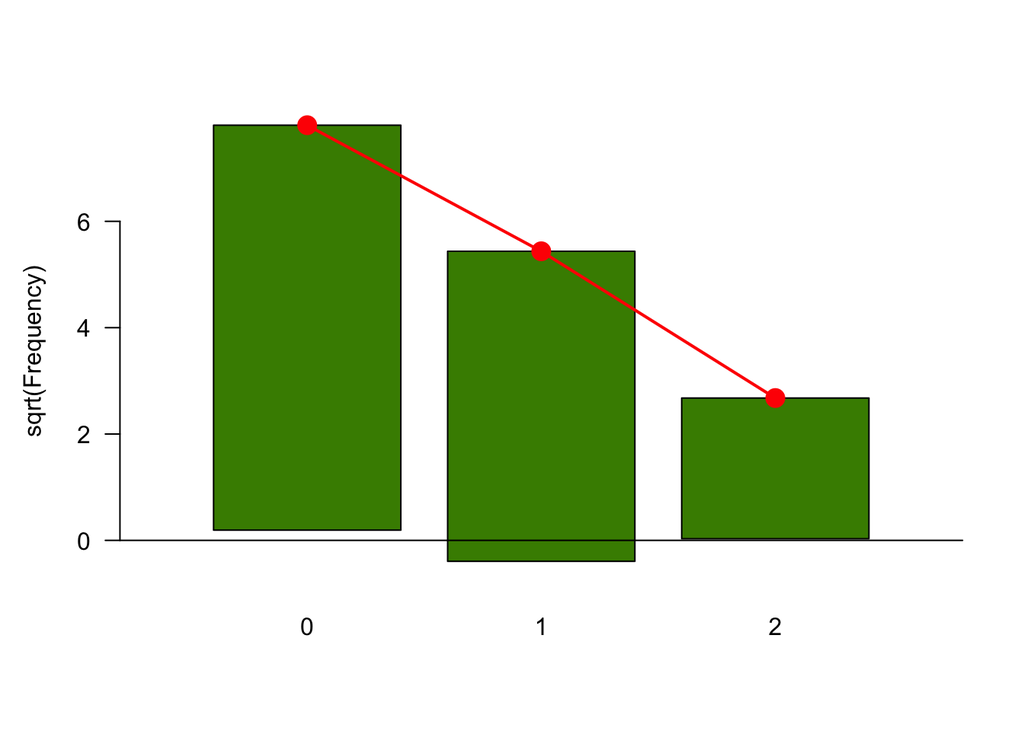

```r
gf1 = goodfit( e99, "poisson")
rootogram(gf1, xlab = "", rect_gp = gpar(fill = "chartreuse4"))
```

##### Question

To calibrate what such a plot looks like with a known Poisson variable, use rpois with λ 0.05 to generate 100 Poisson distributed numbers and draw their rootogram.

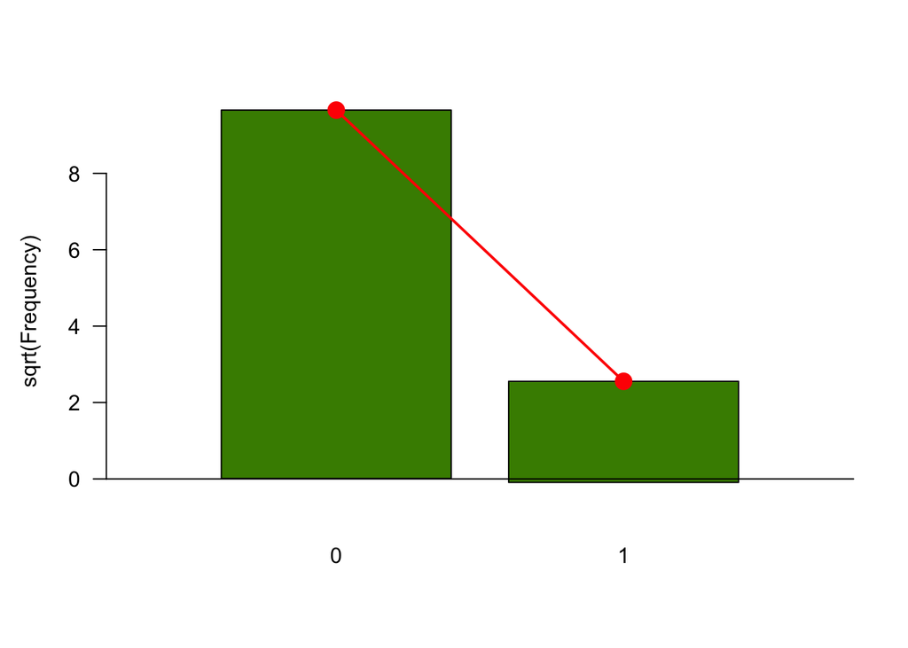

```r
fish <- rpois(100, 0.05)
gf.fish = goodfit( fish, "poisson")
rootogram(gf.fish, xlab = "", rect_gp = gpar(fill = "chartreuse4"))
```

##### Estimating the parameter of the Poisson distribution

What value for the Poisson mean makes the data the most probable?

1. Tally outcomes.

```r
table(e100)
```

```
## e100
##  0  1  2  7
## 58 34  7  1
```

2. Try out different values for Poisson mean to find which fits best to our observed values.

```r
table(rpois(100, 3))
```

```
##
##  0  1  2  3  4  5  6  7  8
## 10 20 23 15 13  8  6  2  3
```

```r
table(rpois(100, 2))
```

```
##
##  0  1  2  3  4  5  6  8
## 17 28 23 25  2  3  1  1
```

```r
table(rpois(100, 1))
```

```
##
##  0  1  2  3  4
## 38 33 14 10  5
```

```r
table(rpois(100, 0))
```

```
##
##   0
## 100
```

Instead of blindly trying out different values, we can see what value maximizes the probability of observing our data. We do this by calculating the probability of seeing the data if the value of the Poisson parameter is m.  
Since we suppose the data derive from independent draws, this probability is simply the product of individual probabilities.  
Therefore, for m=3:

```r
prod(dpois(c(0, 1, 2, 7), lambda = 3) ^ (c(58, 34, 7, 1)))
```

```
## [1] 1.392143e-110
```

##### Question

Computer the probability for m=0,1,2.

```r
prod(dpois(c(0, 1, 2, 7), lambda = 0) ^ (c(58, 34, 7, 1)))
```

```
## [1] 0
```

```r
prod(dpois(c(0, 1, 2, 7), lambda = 1) ^ (c(58, 34, 7, 1)))
```

```
## [1] 5.766487e-50
```

```r
prod(dpois(c(0, 1, 2, 7), lambda = 2) ^ (c(58, 34, 7, 1)))
```

```
## [1] 7.728814e-77
```

```r
prod(dpois(c(0, 1, 2, 7), lambda = 0.4) ^ (c(58, 34, 7, 1)))
```

```
## [1] 8.5483e-46
```

Instead of working with multiplications of a hundred small numbers, it is convenient to take the logarithm. Since the logarithm is strictly increasing, if there is a point where the logarithm achieves its maximum within an interval it will also be the maximum for the probability.

Illustion using a function to compute the likelihood of many poisson values.

```r
loglikelihood  =  function(lambda, data = e100) {
  sum(log(dpois(data, lambda)))
}
```

Then use the function to compute lambda=0.05 to lambda=0.95

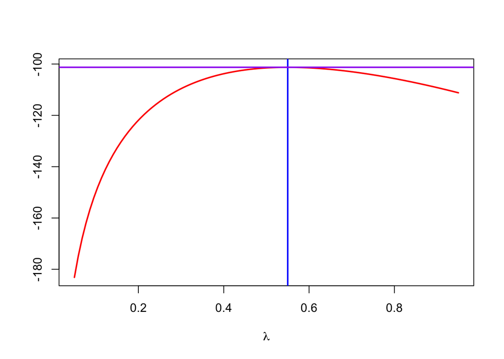

```r
lambdas = seq(0.05, 0.95, length = 100)
loglik = vapply(lambdas, loglikelihood, numeric(1))
plot(lambdas, loglik, type = "l", col = "red", ylab = "", lwd = 2,
     xlab = expression(lambda))
m0 = mean(e100)
abline(v = m0, col = "blue", lwd = 2)
abline(h = loglikelihood(m0), col = "purple", lwd = 2)
```

```r
m0
```

```
## [1] 0.55
```

##### Question

There is a short cut to this. The **goodfit** function.

```r
gf  =  goodfit(e100, "poisson")
gf$par
```

```
## $lambda
## [1] 0.55
```

goodfit output components:  
observed - number of observations of each count  
count - bins of number of occurances  
fitted - probability of observing each count  
type - type of distribution  
method - type of estimate (ML- maximum likelihood) df- degrees of freedom  
par - best fitting lambda paramter

### 2.3.1 Classical statistics for classical data

What is the value of modeling with a known distribution? For instance, why is it interesting to know a variable has a Poisson distribution?

Another useful direction is **regression**. We may be interested in knowing how our count-based response variable (e.g., the result of counting sequencing reads) depends on a continuous covariate, say, temperature or nutrient concentration.

You may already have encountered **linear regression**, where our model is that the response variable y depends on the covariate x via the equation y = ax + b + e, with parameters a and b (that we need to estimate), and with residuals e whose probability model is a normal distribution (whose variance we usually also need to estimate).

For **count data** the same type of regression model is possible, although the probability distribution for the residuals then needs to be **non-normal**. In that case we use the **generalized linear models** framework.

## 2.4 Binomial distributions and maximum likelihood

In a binomial distribution there are two parameters: the number of trials n, which is typically known, and the probability p of seeing a 1 in a trial. This probability is often unknown.

##### Example

Suppose we take a sample of n=120 males and test them for red-green colorblindness. We can code the data as 0 if the subject is not colorblind and 1 if he is. We summarize the data by the table.

```r
cb  =  c(rep(0, 110), rep(1, 10))
table(cb)
```

```
## cb
##   0   1
## 110  10
```

What is the most likely value of p?  
As before in the case of the Poisson, if we compute the likelihood for many possible p, we can plot it and see where its maximum falls.

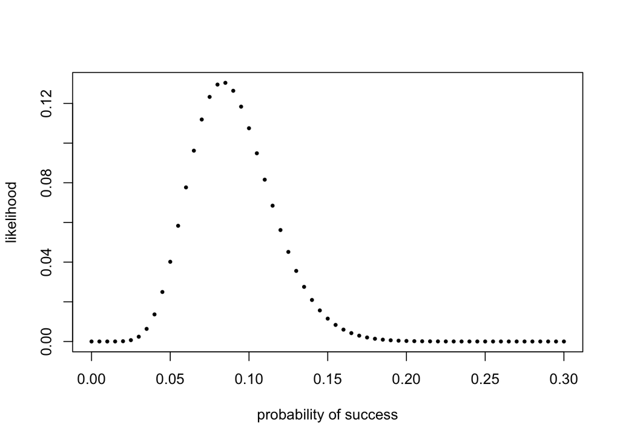

```r
probs  =  seq(0, 0.3, by = 0.005)
likelihood = dbinom(sum(cb), prob = probs, size = length(cb))
plot(probs, likelihood, pch = 16, xlab = "probability of success",
       ylab = "likelihood", cex=0.6)
```

```r
probs[which.max(likelihood)]
```

```
## [1] 0.085
```

##### Likelihood for the binomial distribution

Likelihood and the probability are the same mathematical function, only interpreted in different ways.

Likelihood - tells us how probable it is to see a particular set of values of the data, given the parameters.  
Probability - consider the data as fixed, and ask for the particular parameter value that makes the data more likely.

A function to calculate likelihood:

```r
loglikelihood = function(theta, n = 300, k = 40) {
  115 + k * log(theta) + (n - k) * log(1 - theta)
}
```

We can use this function to help us plot θ from 0 to 1.

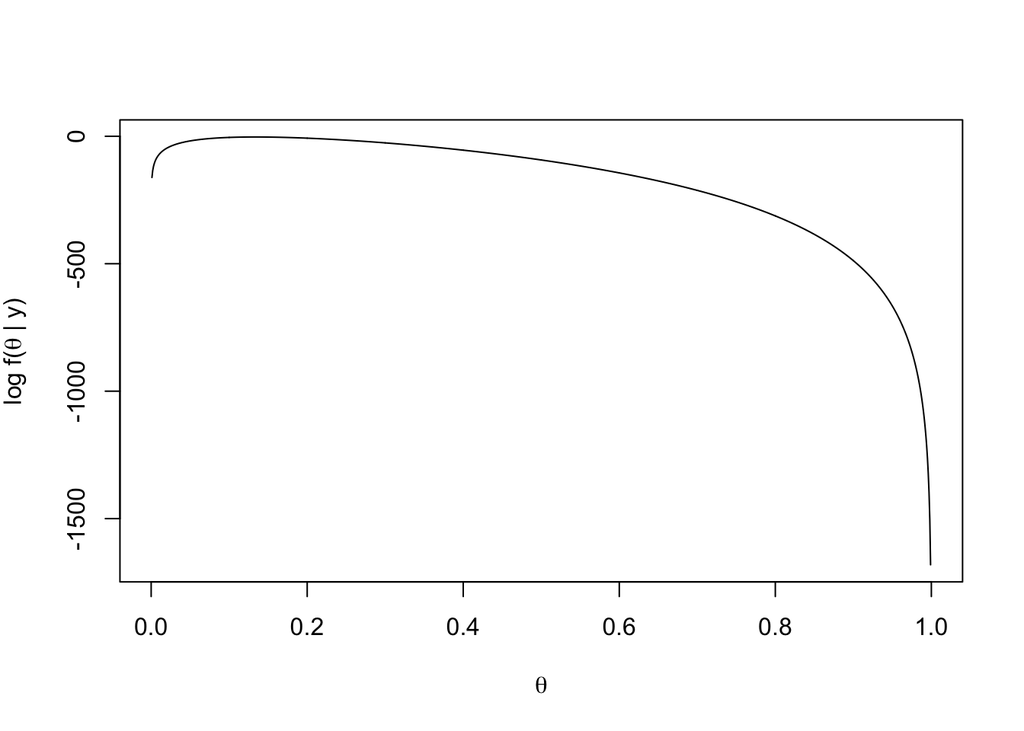

```r
thetas = seq(0, 1, by = 0.001)
plot(thetas, loglikelihood(thetas), xlab = expression(theta),
  ylab = expression(paste("log f(", theta, " | y)")),type = "l")
```

## 2.5 More boxes:multinomial data

### 2.5.1 DNA count modeling: base pairs

Can use binomial function to look at differences in counts between purines (A and G) and pyrimidines (C and T).  
Need a multinomial function to look at each nucleotide separately (A, C, G, T).

### 2.5.2 Nucleotide bias

In this section we will combine estimation and testing by simulation in a real example of *S. aureus*.

```r
library("Biostrings")
staph = readDNAStringSet("staphsequence.ffn.txt", "fasta")
```

Look at the first gene and frequency of each nucleotide in the first gene.

```r
staph[1]
```

```
##   A DNAStringSet instance of length 1
##     width seq                                          names
## [1]  1362 ATGTCGGAAAAAGAAATTTGG...AAGAAATAAGAAATGTATAA lcl|NC_002952.2_c...
```

```r
letterFrequency(staph[[1]], letters = "ACGT", OR = 0)
```

```
##   A   C   G   T
## 522 219 229 392
```

The double square brackets allow us to access the DNA string of length n characters, where the single brackets outputs a single string.

Test whether the nucleotides in gene 1 of *S. aureus* are equally distrubuted:

```r
nucfreq <- alphabetFrequency(staph[[1]], baseOnly=TRUE)
nucprob <- nucfreq/length(staph[[1]])
chisq.test(nucfreq[1:4], y=NULL, rep(1/4,4))
```

```
##
##  Chi-squared test for given probabilities
##
## data:  nucfreq[1:4]
## X-squared = 184.4, df = 3, p-value < 2.2e-16
```

Does selective pressure vary between the first 10 genes? ie. Do nucleotide frequencies vary between them.

```r
letterFrq = vapply(staph, letterFrequency, FUN.VALUE = numeric(4),
         letters = "ACGT", OR = 0)
colnames(letterFrq) = paste0("gene", seq(along = staph))
tab10 = letterFrq[, 1:10]
computeProportions = function(x) { x/sum(x) }
prop10 = apply(tab10, 2, computeProportions)
round(prop10, digits = 2)
```

```
##   gene1 gene2 gene3 gene4 gene5 gene6 gene7 gene8 gene9 gene10
## A  0.38  0.36  0.35  0.37  0.35  0.33  0.33  0.34  0.38   0.27
## C  0.16  0.16  0.13  0.15  0.15  0.15  0.16  0.16  0.14   0.16
## G  0.17  0.17  0.23  0.19  0.22  0.22  0.20  0.21  0.20   0.20
## T  0.29  0.31  0.30  0.29  0.27  0.30  0.30  0.29  0.28   0.36
```

```r
p0 = rowMeans(prop10)
p0
```

```
##         A         C         G         T
## 0.3470531 0.1518313 0.2011442 0.2999714
```

Use a monte carlo simulation to determine whether the nucleotide frequencies observed in these 10 genes follow the expected distribution. We compute the expected frequencies by taking the outer product of the vector of probabilities (p0) with the sum of nucletoide counts from each of the 10 columns.

```r
cs = colSums(tab10)
cs
```

```
##  gene1  gene2  gene3  gene4  gene5  gene6  gene7  gene8  gene9 gene10
##   1362   1134    246   1113   1932   2661    831   1515   1287    696
```

```r
expectedtab10 = outer(p0, cs, FUN = "*")
round(expectedtab10)
```

```
##   gene1 gene2 gene3 gene4 gene5 gene6 gene7 gene8 gene9 gene10
## A   473   394    85   386   671   924   288   526   447    242
## C   207   172    37   169   293   404   126   230   195    106
## G   274   228    49   224   389   535   167   305   259    140
## T   409   340    74   334   580   798   249   454   386    209
```

```r
#create a random table with the correct column sums using the rmultinom function.
#This table is generated according to the null hypothesis that the true proportions are given by p0.
randomtab10 = sapply(cs, function(s) { rmultinom(1, s, p0) } )
all(colSums(randomtab10) == cs)
```

```
## [1] TRUE
```

```r
#repeat this 1000 times
stat = function(obsvd, exptd = 20 * pvec) {
   sum((obsvd - exptd)^2 / exptd)
}
B = 1000
simulstat = replicate(B, {
  randomtab10 = sapply(cs, function(s) { rmultinom(1, s, p0) })
  stat(randomtab10, expectedtab10)
})
S1 = stat(tab10, expectedtab10)
sum(simulstat >= S1)
```

```
## [1] 0
```

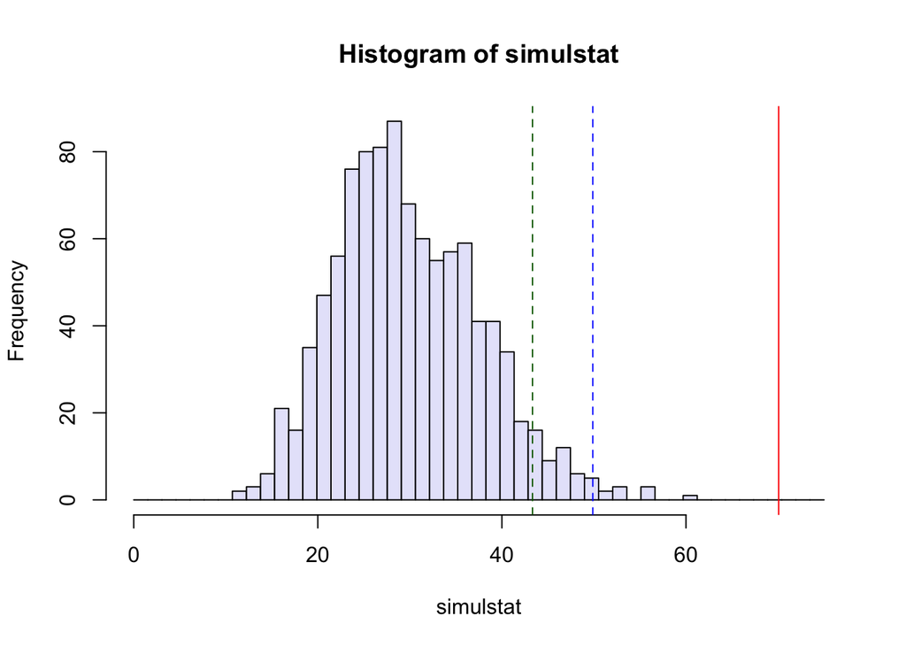

```r
#make histogram
hist(simulstat, col = "lavender", breaks = seq(0, 75, length.out=50))
abline(v = S1, col = "red")
abline(v = quantile(simulstat, probs = c(0.95, 0.99)),
       col = c("darkgreen", "blue"), lty = 2)
```

## 2.6 The χ2 distribution

The theoretical distribution of the simulstat statistic is called the χ2 (chi-squared) distribution. The chi-squared distribution is particularly good if the counts in the table are large.

We can check how well theory and simulation match up in our case using another visual goodness-of-fit tool: the (QQ) plot. This method is based on the quantiles of each of the distributions.

### 2.6.1 Intermezzo: quantiles and the quantile-quantile plot

#### Question

1. Compare the simulstat values and 1000 randomly generated χ2 30 random numbers by displaying them in histograms with 50 bins each.

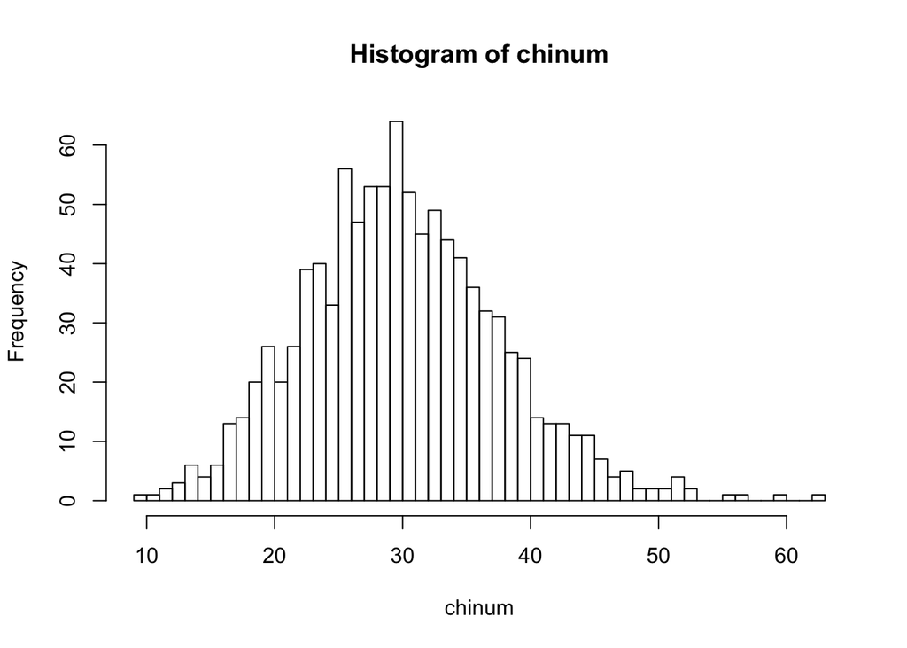

```r
#generate 1000 chisquared numbers
chinum <- rchisq(1000, 30, ncp = 0)
hist(chinum, breaks=50)
```

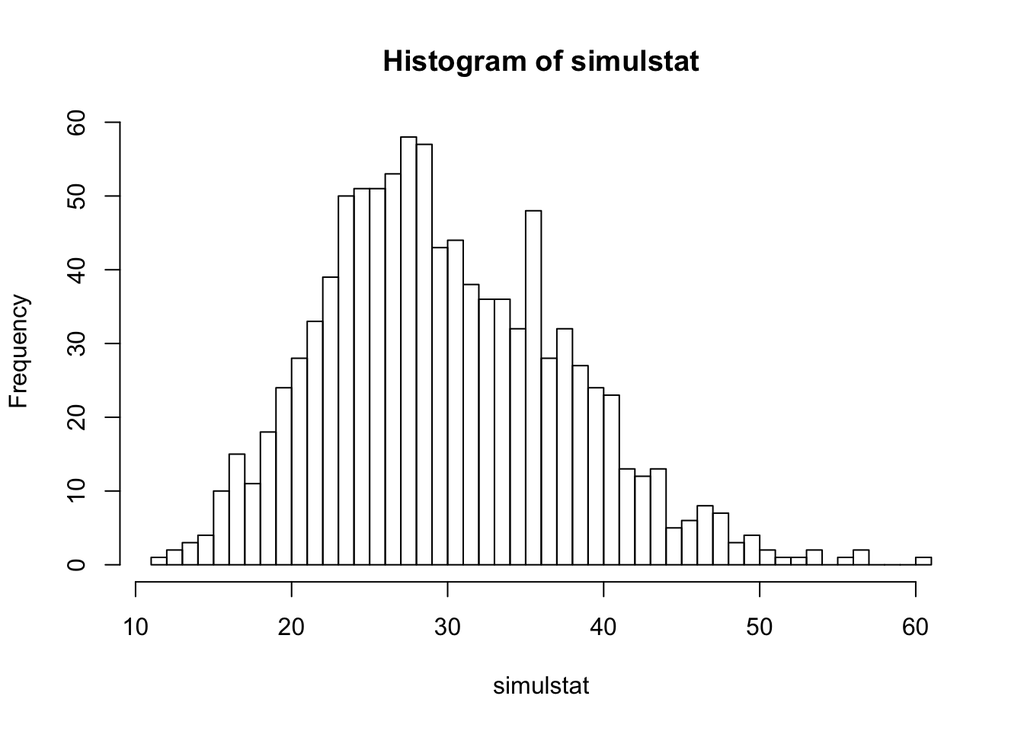

```r
hist(simulstat, breaks=50, plot.new())
```

2. Compute the quantiles of the simulstat values and compare them to those of the χ2 30 distribution. Hint:

```r
qs = ppoints(1000)
quantile(simulstat, qs)
```

```
##    0.05%    0.15%    0.25%    0.35%    0.45%    0.55%    0.65%    0.75%
## 11.67277 12.38867 12.87893 13.23284 13.65677 13.99050 14.37431 14.67589
##    0.85%    0.95%    1.05%    1.15%    1.25%    1.35%    1.45%    1.55%
## 14.83695 15.08311 15.27464 15.38530 15.51067 15.61917 15.67235 15.73622
##    1.65%    1.75%    1.85%    1.95%    2.05%    2.15%    2.25%    2.35%
## 15.83543 15.93143 15.97495 16.08207 16.20474 16.21716 16.22615 16.32415
##    2.45%    2.55%    2.65%    2.75%    2.85%    2.95%    3.05%    3.15%
## 16.49017 16.57578 16.61555 16.64886 16.66350 16.69860 16.77665 16.86108
##    3.25%    3.35%    3.45%    3.55%    3.65%    3.75%    3.85%    3.95%
## 16.94241 16.99440 17.10145 17.26709 17.31959 17.34845 17.46154 17.58446
##    4.05%    4.15%    4.25%    4.35%    4.45%    4.55%    4.65%    4.75%
## 17.67416 17.75105 17.77939 17.83252 17.87381 17.95204 18.12012 18.28475
##    4.85%    4.95%    5.05%    5.15%    5.25%    5.35%    5.45%    5.55%
## 18.43581 18.52326 18.54390 18.57454 18.61751 18.64852 18.65458 18.66266
##    5.65%    5.75%    5.85%    5.95%    6.05%    6.15%    6.25%    6.35%
## 18.67313 18.72351 18.77983 18.80363 18.84547 18.88176 18.92470 18.98777
##    6.45%    6.55%    6.65%    6.75%    6.85%    6.95%    7.05%    7.15%
## 19.05964 19.10525 19.14768 19.20232 19.22404 19.27525 19.32009 19.35915
##    7.25%    7.35%    7.45%    7.55%    7.65%    7.75%    7.85%    7.95%
## 19.43077 19.47046 19.48103 19.51555 19.57791 19.60674 19.63781 19.74704
##    8.05%    8.15%    8.25%    8.35%    8.45%    8.55%    8.65%    8.75%
## 19.84913 19.86852 19.90158 19.92604 19.93788 19.95309 19.97358 19.99712
##    8.85%    8.95%    9.05%    9.15%    9.25%    9.35%    9.45%    9.55%
## 20.06306 20.17551 20.22586 20.24310 20.27820 20.33212 20.36694 20.39460
##    9.65%    9.75%    9.85%    9.95%   10.05%   10.15%   10.25%   10.35%
## 20.40861 20.42959 20.44917 20.48458 20.50893 20.54663 20.59675 20.61994
##   10.45%   10.55%   10.65%   10.75%   10.85%   10.95%   11.05%   11.15%
## 20.64461 20.69344 20.74546 20.76186 20.78904 20.79941 20.80499 20.84835
##   11.25%   11.35%   11.45%   11.55%   11.65%   11.75%   11.85%   11.95%
## 20.91082 20.93500 20.97072 21.01129 21.04009 21.05747 21.07975 21.10949
##   12.05%   12.15%   12.25%   12.35%   12.45%   12.55%   12.65%   12.75%
## 21.14989 21.18101 21.21480 21.25994 21.27238 21.28365 21.29954 21.30870
##   12.85%   12.95%   13.05%   13.15%   13.25%   13.35%   13.45%   13.55%
## 21.33844 21.39102 21.43928 21.44954 21.47845 21.53215 21.58810 21.68269
##   13.65%   13.75%   13.85%   13.95%   14.05%   14.15%   14.25%   14.35%
## 21.76400 21.78705 21.79789 21.80172 21.81207 21.82105 21.83348 21.85158
##   14.45%   14.55%   14.65%   14.75%   14.85%   14.95%   15.05%   15.15%
## 21.85649 21.86466 21.90225 21.96769 22.01083 22.05054 22.05755 22.07209
##   15.25%   15.35%   15.45%   15.55%   15.65%   15.75%   15.85%   15.95%
## 22.08332 22.09152 22.09820 22.12381 22.16670 22.22366 22.27043 22.28108
```

[output cut: 195 more lines]

```
## 42.36584 42.41242 42.46722 42.60138 42.70025 42.73895 42.79095 42.86200
##   94.45%   94.55%   94.65%   94.75%   94.85%   94.95%   95.05%   95.15%
## 42.96092 43.02544 43.08479 43.18073 43.24072 43.29044 43.34581 43.40289
##   95.25%   95.35%   95.45%   95.55%   95.65%   95.75%   95.85%   95.95%
## 43.47248 43.55857 43.71576 43.81749 43.82946 43.93687 44.02631 44.22436
##   96.05%   96.15%   96.25%   96.35%   96.45%   96.55%   96.65%   96.75%
## 44.60757 44.87444 44.98409 45.18220 45.36227 45.52699 45.77266 45.89268
##   96.85%   96.95%   97.05%   97.15%   97.25%   97.35%   97.45%   97.55%
## 46.01363 46.15760 46.43646 46.68919 46.73385 46.75098 46.86413 46.97893
##   97.65%   97.75%   97.85%   97.95%   98.05%   98.15%   98.25%   98.35%
## 47.05215 47.14029 47.20519 47.33193 47.44238 47.47485 47.57360 47.90106
##   98.45%   98.55%   98.65%   98.75%   98.85%   98.95%   99.05%   99.15%
## 48.20666 48.57354 49.07160 49.40484 49.66903 49.83989 50.10592 50.43240
##   99.25%   99.35%   99.45%   99.55%   99.65%   99.75%   99.85%   99.95%
## 50.81815 51.60551 52.80378 53.52839 54.36541 55.64611 56.23048 58.41468
```

```r
quantile(qchisq(qs, df = 30), qs)
```

```
##    0.05%    0.15%    0.25%    0.35%    0.45%    0.55%    0.65%    0.75%
## 11.44499 12.42474 13.00348 13.43248 13.77892 14.07213 14.32785 14.55557
##    0.85%    0.95%    1.05%    1.15%    1.25%    1.35%    1.45%    1.55%
## 14.76151 14.94996 15.12404 15.28608 15.43786 15.58079 15.71601 15.84443
##    1.65%    1.75%    1.85%    1.95%    2.05%    2.15%    2.25%    2.35%
## 15.96681 16.08379 16.19590 16.30361 16.40731 16.50735 16.60401 16.69757
##    2.45%    2.55%    2.65%    2.75%    2.85%    2.95%    3.05%    3.15%
## 16.78825 16.87627 16.96180 17.04502 17.12607 17.20508 17.28219 17.35749
##    3.25%    3.35%    3.45%    3.55%    3.65%    3.75%    3.85%    3.95%
## 17.43109 17.50308 17.57356 17.64259 17.71024 17.77660 17.84171 17.90563
##    4.05%    4.15%    4.25%    4.35%    4.45%    4.55%    4.65%    4.75%
## 17.96843 18.03014 18.09082 18.15050 18.20923 18.26705 18.32400 18.38009
##    4.85%    4.95%    5.05%    5.15%    5.25%    5.35%    5.45%    5.55%
## 18.43538 18.48989 18.54364 18.59666 18.64899 18.70063 18.75162 18.80198
##    5.65%    5.75%    5.85%    5.95%    6.05%    6.15%    6.25%    6.35%
## 18.85173 18.90088 18.94945 18.99747 19.04495 19.09191 19.13835 19.18431
##    6.45%    6.55%    6.65%    6.75%    6.85%    6.95%    7.05%    7.15%
## 19.22978 19.27478 19.31933 19.36344 19.40712 19.45039 19.49324 19.53570
##    7.25%    7.35%    7.45%    7.55%    7.65%    7.75%    7.85%    7.95%
## 19.57777 19.61946 19.66078 19.70175 19.74237 19.78264 19.82258 19.86219
##    8.05%    8.15%    8.25%    8.35%    8.45%    8.55%    8.65%    8.75%
## 19.90148 19.94047 19.97914 20.01752 20.05561 20.09341 20.13094 20.16819
##    8.85%    8.95%    9.05%    9.15%    9.25%    9.35%    9.45%    9.55%
## 20.20517 20.24189 20.27836 20.31457 20.35054 20.38626 20.42175 20.45701
##    9.65%    9.75%    9.85%    9.95%   10.05%   10.15%   10.25%   10.35%
## 20.49204 20.52684 20.56143 20.59580 20.62996 20.66391 20.69766 20.73121
##   10.45%   10.55%   10.65%   10.75%   10.85%   10.95%   11.05%   11.15%
## 20.76456 20.79772 20.83069 20.86348 20.89608 20.92851 20.96075 20.99282
##   11.25%   11.35%   11.45%   11.55%   11.65%   11.75%   11.85%   11.95%
## 21.02473 21.05646 21.08803 21.11943 21.15068 21.18177 21.21270 21.24349
##   12.05%   12.15%   12.25%   12.35%   12.45%   12.55%   12.65%   12.75%
## 21.27412 21.30460 21.33494 21.36514 21.39519 21.42511 21.45489 21.48453
##   12.85%   12.95%   13.05%   13.15%   13.25%   13.35%   13.45%   13.55%
## 21.51404 21.54343 21.57268 21.60180 21.63080 21.65968 21.68844 21.71707
##   13.65%   13.75%   13.85%   13.95%   14.05%   14.15%   14.25%   14.35%
## 21.74559 21.77399 21.80228 21.83045 21.85851 21.88646 21.91431 21.94204
##   14.45%   14.55%   14.65%   14.75%   14.85%   14.95%   15.05%   15.15%
## 21.96967 21.99720 22.02462 22.05194 22.07916 22.10628 22.13331 22.16023
##   15.25%   15.35%   15.45%   15.55%   15.65%   15.75%   15.85%   15.95%
## 22.18706 22.21380 22.24045 22.26700 22.29346 22.31984 22.34612 22.37232
```

[output cut: 195 more lines]

```
## 42.56774 42.64620 42.72574 42.80639 42.88817 42.97114 43.05532 43.14076
##   94.45%   94.55%   94.65%   94.75%   94.85%   94.95%   95.05%   95.15%
## 43.22749 43.31558 43.40506 43.49598 43.58840 43.68237 43.77795 43.87521
##   95.25%   95.35%   95.45%   95.55%   95.65%   95.75%   95.85%   95.95%
## 43.97422 44.07503 44.17774 44.28241 44.38914 44.49801 44.60912 44.72259
##   96.05%   96.15%   96.25%   96.35%   96.45%   96.55%   96.65%   96.75%
## 44.83851 44.95701 45.07823 45.20229 45.32935 45.45957 45.59314 45.73024
##   96.85%   96.95%   97.05%   97.15%   97.25%   97.35%   97.45%   97.55%
## 45.87109 46.01591 46.16496 46.31851 46.47687 46.64038 46.80942 46.98441
##   97.65%   97.75%   97.85%   97.95%   98.05%   98.15%   98.25%   98.35%
## 47.16581 47.35415 47.55005 47.75416 47.96729 48.19031 48.42428 48.67040
##   98.45%   98.55%   98.65%   98.75%   98.85%   98.95%   99.05%   99.15%
## 48.93011 49.20512 49.49749 49.80971 50.14489 50.50693 50.90084 51.33320
##   99.25%   99.35%   99.45%   99.55%   99.65%   99.75%   99.85%   99.95%
## 51.81290 52.35241 52.96996 53.69395 54.57228 55.69661 57.28409 60.19789
```

#### Question

*All sample quantiles are defined as weighted averages of consecutive order statistics.*

Now that we have an idea what quantiles are, we can do the quantile-quantile plot. We plot the quantiles of the simulstat values, which we simulated under the null hypothesis, against the theoretical null distribution χ2 30:

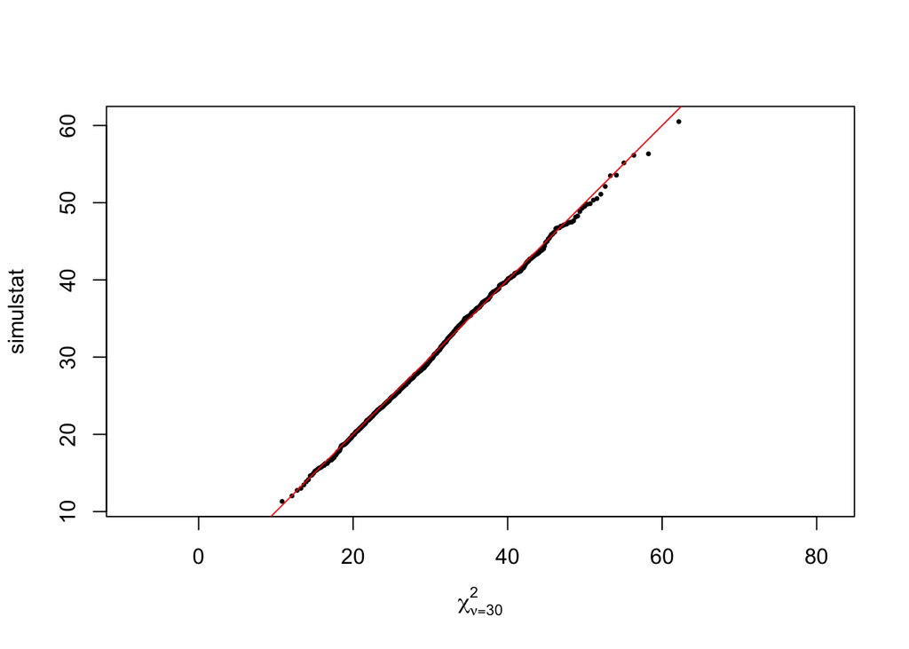

```r
qqplot(qchisq(ppoints(B), df = 30), simulstat, main = "",
  xlab = expression(chi[nu==30]^2), asp = 1, cex = 0.5, pch = 16)
abline(a = 0, b = 1, col = "red")
```

Having convinced ourselves that simulstat is well described by a χ2 30 distribution, we can use that to compute our p-value, i.e., the probability that under the null hypothesis (counts are distributed as multinomial with probabilities pA=0.35, pC=0.15, pG=0.2, pT=0.3) we observe a value as high as S1=70.

```r
1 - pchisq(S1, df = 30)
```

```
## [1] 4.74342e-05
```

## 2.7 Chargaff’s Rule

```r
load("ChargaffTable.RData")
ChargaffTable
```

```
##                   A    T    C    G
## Human-Thymus   30.9 29.4 19.9 19.8
## Mycobac.Tuber  15.1 14.6 34.9 35.4
## Chicken-Eryth. 28.8 29.2 20.5 21.5
## Sheep-liver    29.3 29.3 20.5 20.7
## Sea Urchin     32.8 32.1 17.7 17.3
## Wheat          27.3 27.1 22.7 22.8
## Yeast          31.3 32.9 18.7 17.1
## E.coli         24.7 23.6 26.0 25.7
```

#### Question

**Chargaff’s rule**: The amount of A is equal to the amount of T, the amount of C is equal to the amount of G.

1. Do these data seem to come from equally likely multinomial categories?  
   *No these data do not*
2. Can you suggest an alternative pattern?  
   *Eukaryotes come from one pattern, prokaryotes come from another pattern. Prokaryotes have a greater proportion of G and C in their genome.*
3. Can you do a quantitative analysis of the pattern, perhaps inspired by the simulations above?

```r
statChf = function(x){
  sum((x[, "C"] - x[, "G"])^2 + (x[, "A"] - x[, "T"])^2)
}
chfstat = statChf(ChargaffTable)
permstat = replicate(100000, {
     permuted = t(apply(ChargaffTable, 1, sample))
     colnames(permuted) = colnames(ChargaffTable)
     statChf(permuted)
})
pChf = mean(permstat <= chfstat)
pChf
```

```
## [1] 0.00018
```

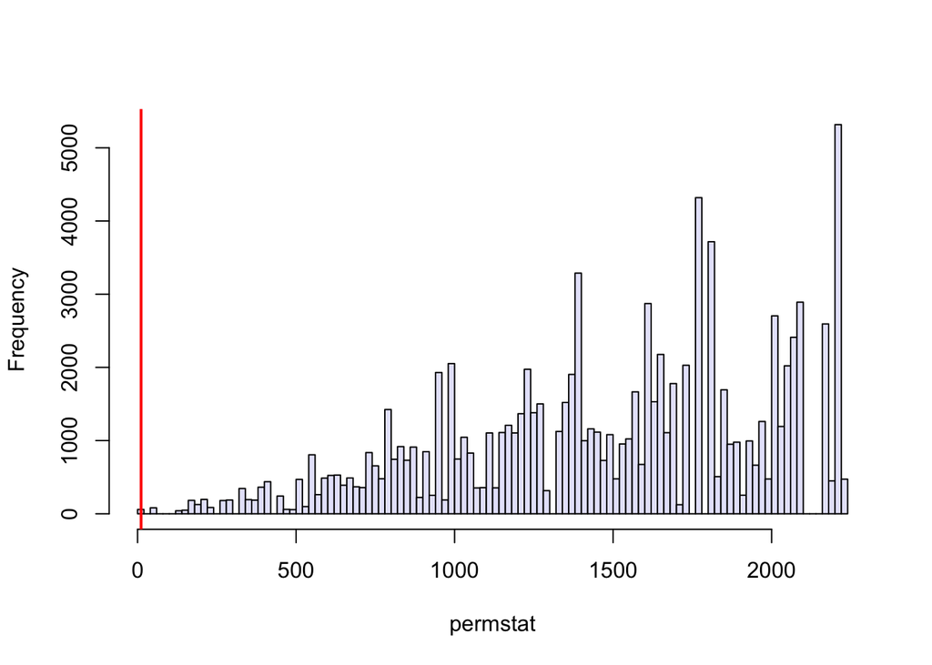

```r
#histogram of our statistic statChf computed from simulations using per-row permutations of the columns
hist(permstat, breaks = 100, main = "", col = "lavender")
abline(v = chfstat, lwd = 2, col = "red")
```

#### Question

When computing pChf, we only looked at the values in the null distribution smaller than the observed value. Why did we do this in a one-sided way here?

### 2.7.1 Two categorical variables

Up to now, we have visited cases where the data are taken from a sample that can be classified into different boxes: the **binomial** for Yes/No binary boxes and the **multinomial distribution** for categorical variables such as A, C, G, T.

However it might be that we measure two (or more) **categorical variables** on a set of subjects, for instance eye color and hair color. We can then cross-tabulate the counts for every combination of eye and hair color. We obtain a table of counts called a contingency table. *This concept is very useful for many biological data types*.

```r
HairEyeColor[,, "Female"]
```

```
##        Eye
## Hair    Brown Blue Hazel Green
##   Black    36    9     5     2
##   Brown    66   34    29    14
##   Red      16    7     7     7
##   Blond     4   64     5     8
```

#### Question

Explore the HairEyeColor object in R. What data type, shape and dimensions does it have?

```r
str(HairEyeColor)
```

```
##  'table' num [1:4, 1:4, 1:2] 32 53 10 3 11 50 10 30 10 25 ...
##  - attr(*, "dimnames")=List of 3
##   ..$ Hair: chr [1:4] "Black" "Brown" "Red" "Blond"
##   ..$ Eye : chr [1:4] "Brown" "Blue" "Hazel" "Green"
##   ..$ Sex : chr [1:2] "Male" "Female"
```

Array with 3 dimensions (hair, eye colour, and sex)

#### Colour blindness and sex

```r
load("Deuteranopia.RData")
```

How do we test whether there is a relationship between sex and the occurrence of color blindness? We postulate the null model with two independent binomials: one for sex and one for color blindness. Under this model we can estimate all the cells’ multinomial probabilities, and we can compare the observed counts to the expected ones. This is done through the **chisq.test function** in R.

```r
chisq.test(Deuteranopia)
```

```
##
##  Pearson's Chi-squared test with Yates' continuity correction
##
## data:  Deuteranopia
## X-squared = 12.255, df = 1, p-value = 0.0004641
```

We’ll see another test for this type of data called **Fisher’s exact test** (also known as the hypergeometric test) in section 10.3.2. This test is widely used for testing the over-representations of certain types of genes in a list of significantly expressed ones.

### 2.7.2 A special multinomial: Hardy-Weinberg equilibrium

```r
library("HardyWeinberg")
#this is genotype frequency data of blood group alleles from Mourant, Kopec, and Domaniewska-Sobczak
data("Mourant")
Mourant[214:216,]
```

```
##     Population    Country Total  MM  MN  NN
## 214    Oceania Micronesia   962 228 436 298
## 215    Oceania Micronesia   678  36 229 413
## 216    Oceania     Tahiti   580 188 296  96
```

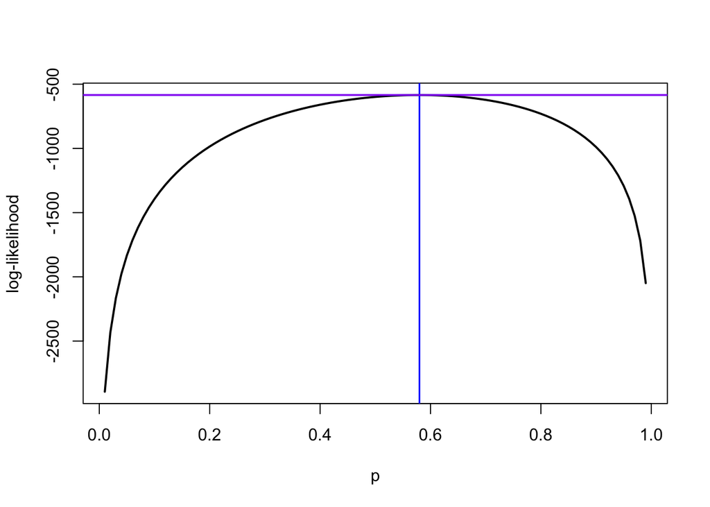

```r
#put allelic frequencies into vectors
nMM = Mourant$MM[216]
nMN = Mourant$MN[216]
nNN = Mourant$NN[216]
#calculate log prob
loglik = function(p, q = 1 - p) {
  2 * nMM * log(p) + nMN * log(2*p*q) + 2 * nNN * log(q)
}
#create vector of freq
xv = seq(0.01, 0.99, by = 0.01)
#take log likelihood of those freqs
yv = loglik(xv)
#plot freq against log likelihood
plot(x = xv, y = yv, type = "l", lwd = 2,
     xlab = "p", ylab = "log-likelihood")
#make like for frequency which maxes prob
imax = which.max(yv)
#plot max x
abline(v = xv[imax], h = yv[imax], lwd = 1.5, col = "blue")
#plot max y
abline(h = yv[imax], lwd = 1.5, col = "purple")
```

The maximum likelihood estimate for the probabilities in the multinomial is also obtained by using the observed frequencies as in the binomial case, however the estimates have to account for the relationships between the three probabilities. We can compute ^pMM, ^pMN and ^pNN using the af function from the HardyWeinberg package.

```r
#compute probabilities of seeing our observed frequencies
phat  =  af(c(nMM, nMN, nNN))
#proporotion of M alleles in population
phat
```

```
## [1] 0.5793103
```

```r
#probabilities of observed MM
pMM   =  phat^2
#proportion of N alleles in pop
qhat  =  1 - phat
#expected proportion of each allele
pHW = c(MM = phat^2, MN = 2*phat*qhat, NN = qhat^2)
pHW
```

```
##        MM        MN        NN
## 0.3356005 0.4874197 0.1769798
```

```r
#expected number of individuals
sum(c(nMM, nMN, nNN)) * pHW
```

```
##       MM       MN       NN
## 194.6483 282.7034 102.6483
```

Visualize compare these expected values to our observed values.

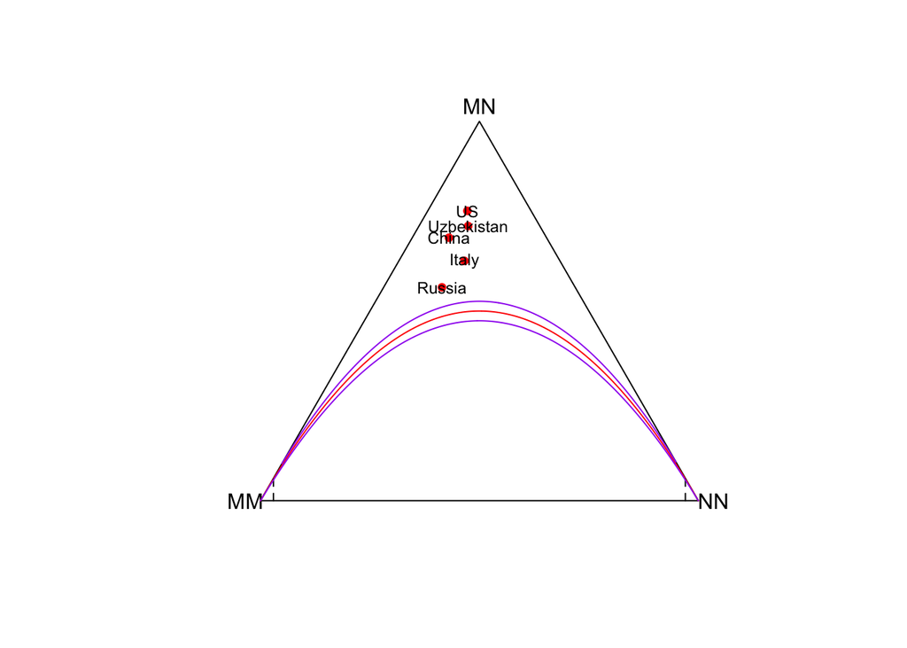

```r
pops = c(1, 69, 128, 148, 192)
genotypeFrequencies = as.matrix(Mourant[, c("MM", "MN", "NN")])
HWTernaryPlot(genotypeFrequencies[pops, ],
        markerlab = Mourant$Country[pops],
        alpha = 0.0001, curvecols = c("red", rep("purple", 4)),
        mcex = 0.75, vertex.cex = 1)
```

This de Finetti plot shows the points as barycenters of the three genotypes using the frequencies as weights on each of the corners of the triangle. The Hardy-Weinberg model is the red curve, the acceptance region is between the two purple lines. We see that the US is the furthest from being in HW equilibrium.

#### Question

Make the ternary plot as in the code above, then add the other data points to it, what do you notice?  
You could back up your discussion using the HWChisq function.

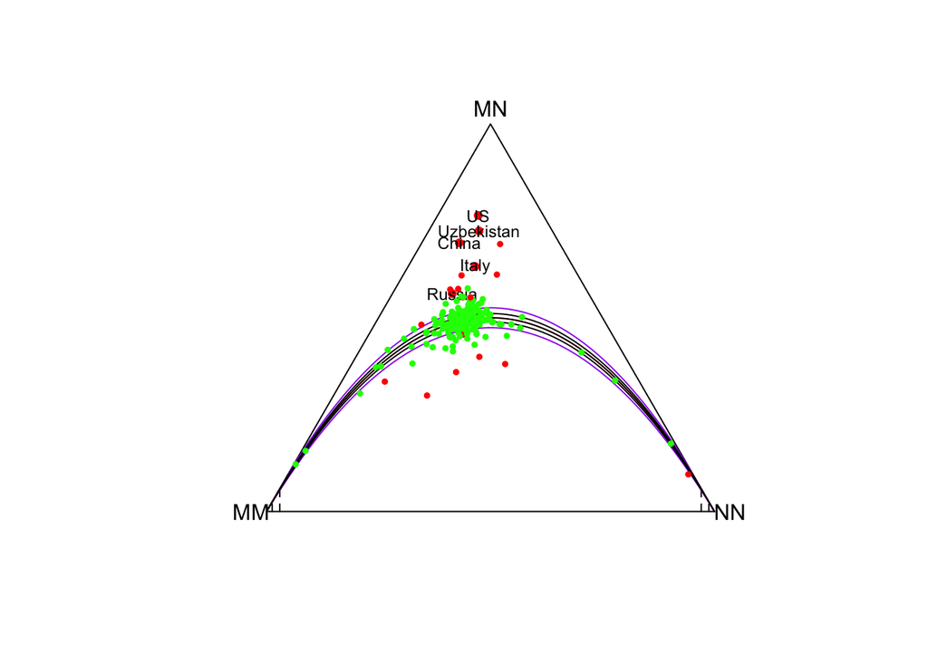

```r
pops = c(1, 69, 128, 148, 192)
genotypeFrequencies = as.matrix(Mourant[, c("MM", "MN", "NN")])
HWTernaryPlot(genotypeFrequencies[pops, ],
        markerlab = Mourant$Country[pops],
        alpha = 0.0001, curvecols = c("red", rep("purple", 4)),
        mcex = 0.75, vertex.cex = 1)
HWTernaryPlot(genotypeFrequencies[-pops, ], alpha = 0.0001,
   newframe = FALSE, cex = 0.5)
```

##### Question

Divide all total frequencies by 50, keeping the same proportions for each of the genotypes, and recreate the ternary plot.  
What happens to the points?  
What happens to the confidence regions and why?

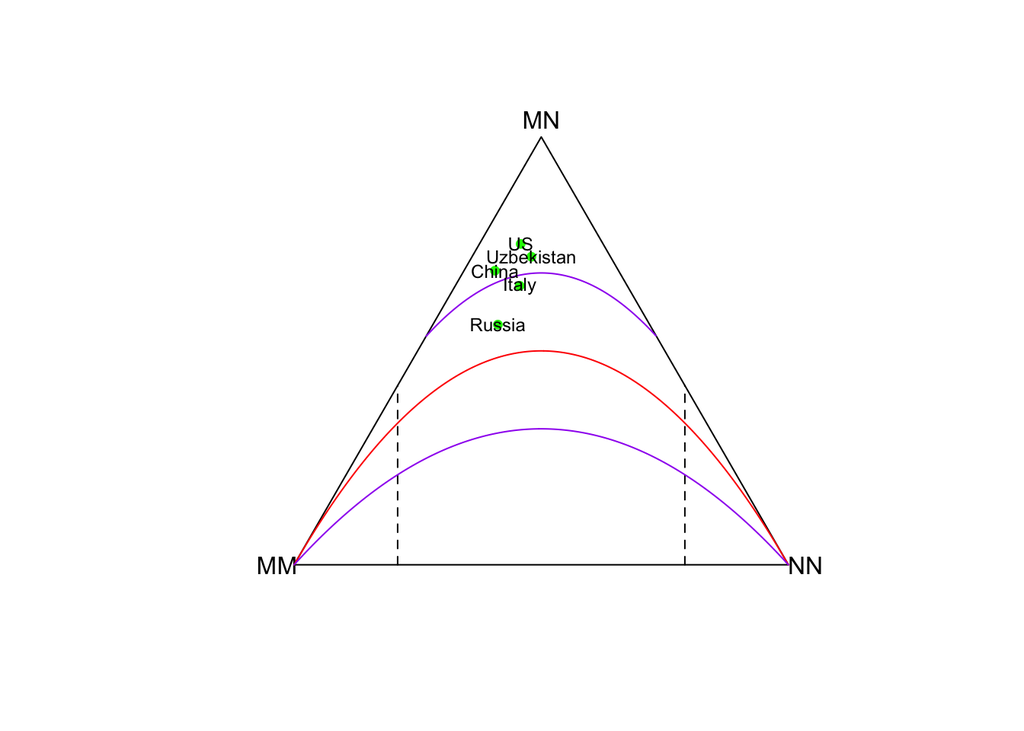

```r
newgf = round(genotypeFrequencies / 50)
HWTernaryPlot(newgf[pops, ],
        markerlab = Mourant$Country[pops],
        alpha = 0.0001, curvecols = c("red", rep("purple", 4)),
        mcex = 0.75, vertex.cex = 1)
```

### 2.7.3 Concatenating several multinomials: sequence motifs and logos

The Kozak Motif is a sequence that occurs close to the start codon ATG of a coding region. The start codon itself always has a fixed spelling but in positions 5 to the left of it, there is a nucleotide pattern in which the letters are quite far from being equally likely.

We summarize this by giving the position weight matrix (PWM) or position-specific scoring matrix (PSSM), which provides the multinomial probabilities at every position. This is encoded graphically by the sequence logo.

```r
library("seqLogo")
load("kozak.RData")
kozak
```

```
##   [,1] [,2] [,3] [,4] [,5] [,6] [,7] [,8] [,9]
## A 0.33 0.25  0.4 0.15 0.20    1    0    0 0.05
## C 0.12 0.25  0.1 0.40 0.40    0    0    0 0.05
## G 0.33 0.25  0.4 0.20 0.25    0    0    1 0.90
## T 0.22 0.25  0.1 0.25 0.15    0    1    0 0.00
```

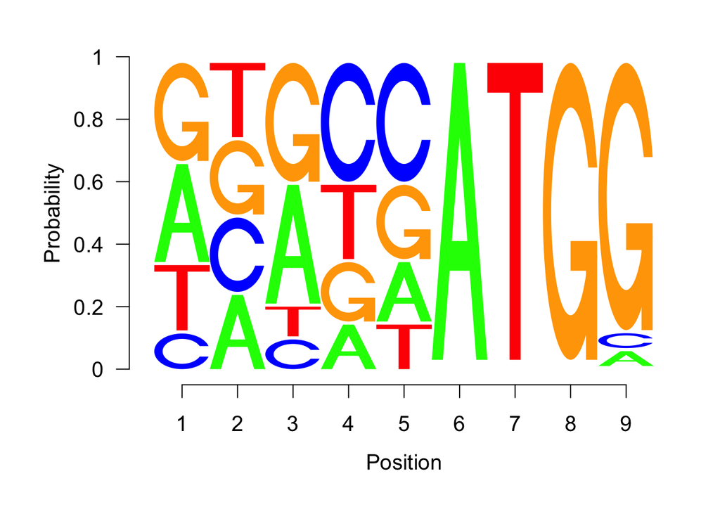

```r
pwm = makePWM(kozak)
seqLogo(pwm, ic.scale = FALSE)
```

## 2.8 Modeling sequential dependencies: Markov chains

Here, we’ll look at an important special case of dependencies between categorical variables: those that occur along a sequence (or “chain”) of categorical variables, e.g., over time or along a biopolymer.

If we want to predict tomorrow’s weather, a reasonably good guess is that it will most likely be the same as today’s weather, in addition we may state the probabilties for various kinds of possible changes. The same reasoning can also be applied in reverse: we could “predict” yesterday’s weather from today’s.. This method for weather forecasting is an example for the Markov assumption: the prediction for tomorrow only depends on the state of things today, but not on yesterday or three weeks ago (all information we could potentially use is already contained in today’s weather).

The weather example also highlights that such an assumption need not necessarily be exactly true, but it should be a good enough assumption.

*The essence of the Markov assumption is that the process has a finite “memory”, so that predictions only need to look back for a finite amount of time.*

Applied to DNA: we may see specific succession of patterns so that pairs of nucleotides, called digrams, say, CG, CA, CC and CT are not equally frequent. For instance, in parts of the genome we see more frequent instances of CA than we would expect under independence:P(CA)≠P(C)P(A)

## 2.9 Bayesian Thinking

The *Bayesian paradigm* is a practical approach where **prior** and **posterior** distributions are used as models of our knowledge before and after collecting some data and making an observation. It is particularly useful for integrating or combining information from different sources.

Suppose we have a certain hypothesis, call it H, and we want to use data to decide whether the hypothesis is true. We can formalize our prior knowledge about H in the form of a prior probability, written P(H). After we see the data, we have the posterior probability. We write it as P(H|D), the probability of H given that we saw D. This may be higher or lower than P(H), depending on what the data D were.

### Haplotypes

A haplotype is a collection of alleles (DNA sequence variants) that are spatially adjacent on a chromosome, are usually inherited together (recombination tends not to disconnect them), and thus are genetically linked. In this case we are looking at linked variants on the Y chromosome.

#### 2.9.1 Example: haplotype frequencies

```r
haplo6=read.table("haplotype6.txt",header = TRUE)
haplo6
```

```
##   Individual DYS19 DXYS156Y DYS389m DYS389n DYS389p
## 1         H1    14       12       4      12       3
## 2         H3    15       13       4      13       3
## 3         H4    15       11       5      11       3
## 4         H5    17       13       4      11       3
## 5         H7    13       12       5      12       3
## 6         H8    16       11       5      12       3
```

We need to find the underlying proportion θ of the haplotype of interest in the population of interest. We are going to consider the occurrence of a haplotype as a `success’ in a binomial distribution using collected observations.

The haplotypes created through the use of these Y-STR profiles are shared between men in the same patriarchal lineages. For these reasons it is possible that two different men share the same profile.

#### 2.9.2 Simulation study of the Bayesian paradigm for the binomial

Instead of assuming that our parameter θ has one single value, the *Bayesian world view* allows us to see it as a draw from a statistical distribution.

When we are looking at a parameter that expresses a proportion or a probability, and which takes its values between 0 and 1, it is convenient to use the **beta distribution**.

Beta distribution function is dependent on on two parameters α and β, making it a very flexible family of distributions (so it can ‘fit’ a lot different situations).

It has a nice mathematical property: if we start with a prior belief on θ that is beta-shaped, observe a dataset of n binomial trials, then update our belief, the posterior distribution on θ will also have a beta distribution, albeit with updated parameters.

#### The distribution of Y

For a given choice of θ, we know what the distribution of Y is. But what is the distribution of Y if θ itself also varies according to some distribution? We call this the *marginal distribution of Y*.

Let’s simulate that:

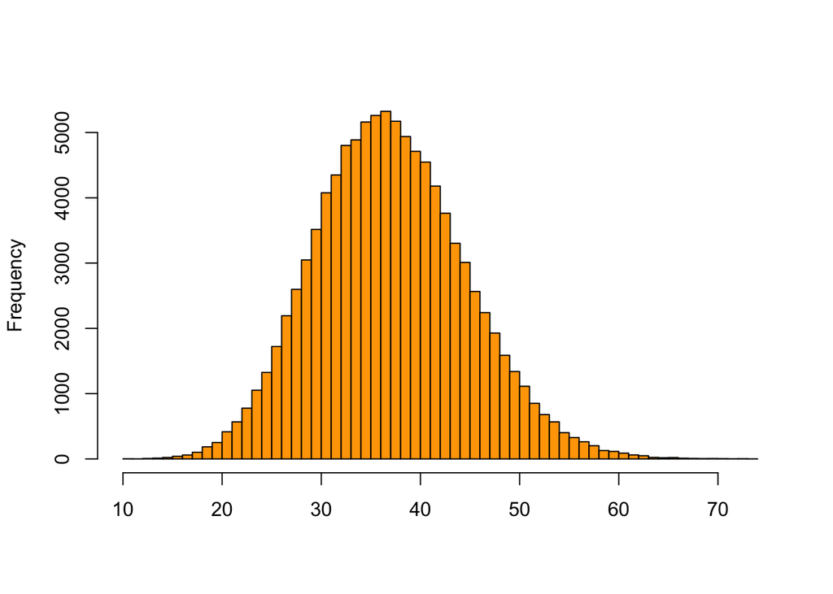

```r
#generate random sample of 100 000 betas
rtheta = rbeta(100000, 50, 350)
#run function th across all elements of rtheta and place in vector y
y = vapply(rtheta, function(th) {
  rbinom(1, prob = th, size = 300)
}, numeric(1))
hist(y, breaks = 50, col = "orange", main = "", xlab = "")
```

#### Question

Verify that we could have gotten the same result as in the above code chunk by using R’s vectorisation capabilities and writing rbinom(length(rtheta), rtheta, size = 300).

#### Histogram of all the thetas such that Y=40: the posterior distribution

So let’s now compute the posterior distribution of θ by conditioning on those outcomes where Y was 40. We compare it to the theoretical posterior, densPostTheory. We use thetas defined above in Section 2.4.

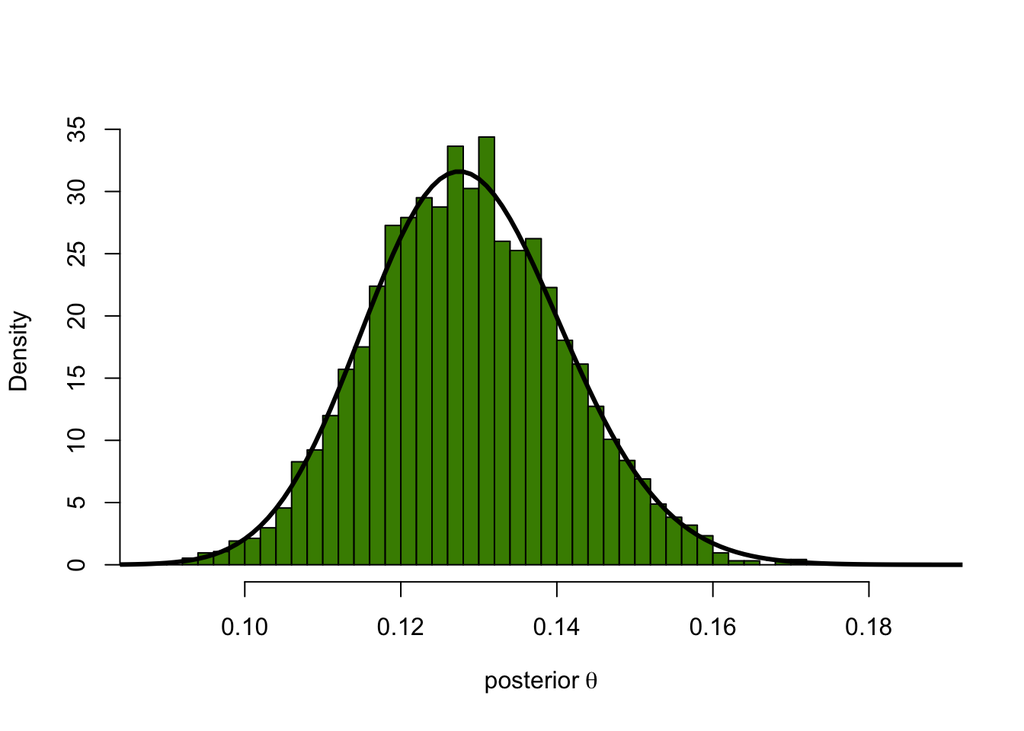

```r
thetaPostEmp = rtheta[ y == 40 ]
hist(thetaPostEmp, breaks = 40, col = "chartreuse4", main = "",
  probability = TRUE, xlab = expression("posterior"~theta))
densPostTheory  =  dbeta(thetas, 90, 610)
lines(thetas, densPostTheory, type="l", lwd = 3)
```

## 2.10 Example: occurrence of a nucleotide pattern in a genome

Let’s look at an example of distributions of distances, which are quasi-continuous.

```r
library("Biostrings")
```

```r
library("BSgenome")
ag = available.genomes()
length(ag)
```

```
## [1] 93
```

```r
ag[1:2]
```

```
## [1] "BSgenome.Alyrata.JGI.v1"
## [2] "BSgenome.Amellifera.BeeBase.assembly4"
```

Use E.coli to examine Shine-Dalgarno seq

```r
library("BSgenome.Ecoli.NCBI.20080805")
Ecoli
```

```
## E. coli genome:
## # organism: Escherichia coli (E. coli)
## # provider: NCBI
## # provider version: 2008/08/05
## # release date: NA
## # release name: NA
## # 13 sequences:
## #   NC_008253 NC_008563 NC_010468 NC_004431 NC_009801 NC_009800 NC_002655
## #   NC_002695 NC_010498 NC_007946 NC_010473 NC_000913 AC_000091
## # (use 'seqnames()' to see all the sequence names, use the '$' or '[['
## # operator to access a given sequence)
```

```r
shineDalgarno = "AGGAGGT"
ecoli = Ecoli$NC_010473
```

We can count the Shine-Dalgarno sequence pattern occurrence in windows of width 50000 using the countPattern function.

```r
window = 50000
starts = seq(1, length(ecoli) - window, by = window)
ends   = starts + window - 1
numMatches = vapply(seq_along(starts), function(i) {
  countPattern(shineDalgarno, ecoli[starts[i]:ends[i]],
               max.mismatch = 0)
  }, numeric(1))
table(numMatches)
```

```
## numMatches
##  0  1  2  3  4
## 48 32  8  3  2
```

#### Question

What distribution might fit this table? *Poisson*

```r
library("vcd")
gf = goodfit(numMatches, "poisson")
summary(gf)
```

```
##
##   Goodness-of-fit test for poisson distribution
##
##                       X^2 df  P(> X^2)
## Likelihood Ratio 4.134932  3 0.2472577
```

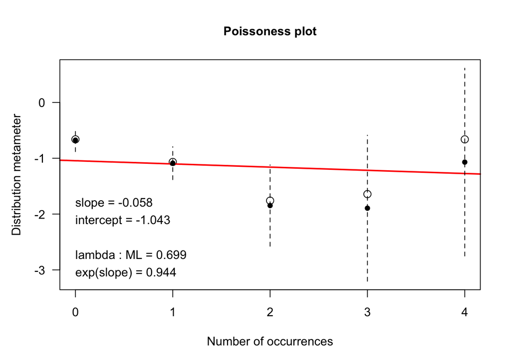

```r
distplot(numMatches, type = "poisson")
```

We can inspect the matches using the matchPattern function.

```r
sdMatches = matchPattern(shineDalgarno, ecoli, max.mismatch = 0)
sdMatches
```

```
##   Views on a 4686137-letter DNAString subject
## subject: AGCTTTTCATTCTGACTGCAACGGGCAATATG...CAAATAAAAAACGCCTTAGTAAGTATTTTTC
## views:
##        start     end width
##  [1]   56593   56599     7 [AGGAGGT]
##  [2]  199644  199650     7 [AGGAGGT]
##  [3]  202176  202182     7 [AGGAGGT]
##  [4]  214433  214439     7 [AGGAGGT]
##  [5]  217429  217435     7 [AGGAGGT]
##  ...     ...     ...   ... ...
## [61] 4438786 4438792     7 [AGGAGGT]
## [62] 4498085 4498091     7 [AGGAGGT]
## [63] 4536658 4536664     7 [AGGAGGT]
## [64] 4546821 4546827     7 [AGGAGGT]
## [65] 4611626 4611632     7 [AGGAGGT]
```

Compute the distance between matches:

```r
betweenmotifs = gaps(sdMatches)
betweenmotifs
```

```
##   Views on a 4686137-letter DNAString subject
## subject: AGCTTTTCATTCTGACTGCAACGGGCAATATG...CAAATAAAAAACGCCTTAGTAAGTATTTTTC
## views:
##        start     end  width
##  [1]       1   56592  56592 [AGCTTTTCATTCTGACTGCAA...AGGTGTCAGAACCCGGCAGAC]
##  [2]   56600  199643 143044 [AAAGCTACCGTTATCCAGAAT...GAGAGCGCCTGCTTTGCACGC]
##  [3]  199651  202175   2525 [CTGCGGTTCGATCCCGCATAG...GGCTAATCCTGGTCGGACATC]
##  [4]  202183  214432  12250 [TAGTGCAATGGCATAAGCCAG...ATCGTGTTATCGCCAGGCTTT]
##  [5]  214440  217428   2989 [TAATAACATGGGCAGGATAAG...AACGAAAAGCCCCTTACTTGT]
##  ...     ...     ...    ... ...
## [62] 4438793 4498084  59292 [GGATTTAATCACGGTAACATT...AGTCATTGCATCGTCAACTTC]
## [63] 4498092 4536657  38566 [AGATCCGGTTGCGGCAGCAAG...TAAATTTGAACTCCAAATACC]
## [64] 4536665 4546820  10156 [GGAATTAAAGAATGCGATGGA...AGTTATACTTTGTATAACTTA]
## [65] 4546828 4611625  64798 [GCAGATGCGTATTACCATAAA...GCGCGCGCATCGCCGAGTGCA]
## [66] 4611633 4686137  74505 [CGAGATCGCGGCAAAAACTCA...ACGCCTTAGTAAGTATTTTTC]
```

Now let’s find a model for the distribution of the gap sizes between motifs. If the motifs occur at random locations, we expect the gap lengths to follow an exponential distribution.

This is because whenever we have independent, random Bernoulli occurrences along a sequence, the gap lengths are exponential. You may be familiar with radioactive decay, where the waiting times between emissions are also exponentially distributed.

The code below assesses this assumption. If the exponential distribution is a good fit, the points should lie roughly on a straight line. The exponential distribution has one parameter, the rate, and the line with slope corresponding to an estimate from the data is also shown.

```r
library("Renext")
```

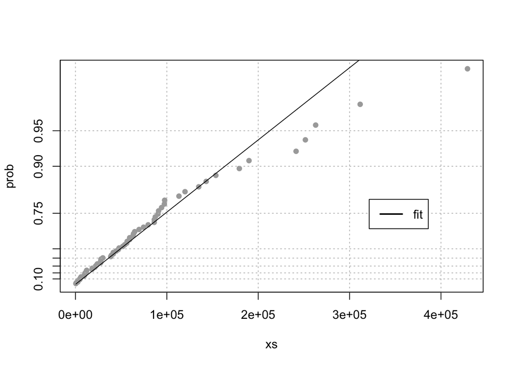

```r
expplot(width(betweenmotifs), rate = 1/mean(width(betweenmotifs)),
        labels = "fit")
```

#### Question

There appears to be a slight deviation from the fitted line in Figure 2.23 at the right tail of the distibution, i.e., for the largest values. What could be the reason?

*I’m not sure.*

### 2.10.1 Modeling in the case of dependencies

Here we are going to put into practice dependency modeling using a Markov chain. We are going to look at regions of chromosome 8 of the human genome and try to discover differences between regions called CpG islands and the rest.

```r
library("BSgenome.Hsapiens.UCSC.hg19")
chr8  =  Hsapiens$chr8
CpGtab = read.table("model-based-cpg-islands-hg19.txt",
                    header = TRUE)
#how many cpgs are there
nrow(CpGtab)
```

```
## [1] 65699
```

```r
#glance at cpg table
head(CpGtab)
```

```
##     chr  start    end length CpGcount GCcontent pctGC obsExp
## 1 chr10  93098  93818    721       32       403 0.559  0.572
## 2 chr10  94002  94165    164       12        97 0.591  0.841
## 3 chr10  94527  95302    776       65       538 0.693  0.702
## 4 chr10 119652 120193    542       53       369 0.681  0.866
## 5 chr10 122133 122621    489       51       339 0.693  0.880
## 6 chr10 180265 180720    456       32       256 0.561  0.893
```

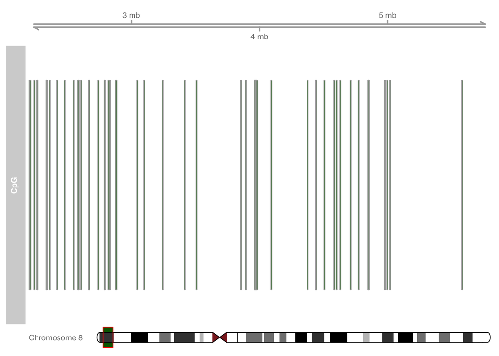

```r
#create IRanges obset with width of cpg islands on chr8
irCpG = with(dplyr::filter(CpGtab, chr == "chr8"),
         IRanges(start = start, end = end))
#create a GRanges object from IRanges object with width of cpgs islands on chr8
grCpG = GRanges(ranges = irCpG, seqnames = "chr8", strand = "+")
genome(grCpG) = "hg19"

#visualize this info on chromosome 8 from 2200000 to 5800000
library("Gviz")
ideo = IdeogramTrack(genome = "hg19", chromosome = "chr8")
plotTracks(
  list(GenomeAxisTrack(),
    AnnotationTrack(grCpG, name = "CpG"), ideo),
    from = 2200000, to = 5800000,
    shape = "box", fill = "#006400", stacking = "dense")
```

```r
#seqs with cpg islands on chr8
CGIview    = Views(unmasked(Hsapiens$chr8), irCpG)
#seqs that do not contain cpg islands on chr8
NonCGIview = Views(unmasked(Hsapiens$chr8), gaps(irCpG))

#convert to DNAStrigSet so that we can apply function dinucleotideFrequency
seqCGI      = as(CGIview, "DNAStringSet")
seqNonCGI   = as(NonCGIview, "DNAStringSet")
#count dinucleotide frequency
dinucCpG    = sapply(seqCGI, dinucleotideFrequency)
dinucNonCpG = sapply(seqNonCGI, dinucleotideFrequency)
dinucCpG[, 1]
```

```
##  AA  AC  AG  AT  CA  CC  CG  CT  GA  GC  GG  GT  TA  TC  TG  TT
##  49 127  55   8 132  44 116 112  54 129 107 100   4 104 112  18
```

```r
dinucNonCpG[, 1]
```

```
##  AA  AC  AG  AT  CA  CC  CG  CT  GA  GC  GG  GT  TA  TC  TG  TT
## 389 351 400 436 498 560 112 603 359 336 403 336 330 527 519 485
```

```r
#sum counts from each section of CGI or nonCGI sequence
NonICounts = rowSums(dinucNonCpG)
IslCounts  = rowSums(dinucCpG)

#For a four state Markov chain as we have, we define the transition matrix as a matrix where the rows are the from state and the columns are the to state.

TI  = matrix( IslCounts, ncol = 4, byrow = TRUE)
TnI = matrix(NonICounts, ncol = 4, byrow = TRUE)
dimnames(TI) = dimnames(TnI) =
  list(c("A", "C", "G", "T"), c("A", "C", "G", "T"))

#We use the counts of numbers of transitions of each type to compute frequencies and put them into two matrices.
#islands
MI = TI /rowSums(TI)
MI
```

```
##            A         C         G         T
## A 0.20457773 0.2652333 0.3897678 0.1404212
## C 0.20128250 0.3442381 0.2371595 0.2173200
## G 0.18657245 0.3145299 0.3450223 0.1538754
## T 0.09802105 0.3352314 0.3598984 0.2068492
```

```r
#not islands
MN = TnI / rowSums(TnI)
MN
```

```
##           A         C          G         T
## A 0.3351380 0.1680007 0.23080886 0.2660524
## C 0.3641054 0.2464366 0.04177094 0.3476871
## G 0.2976696 0.2029017 0.24655406 0.2528746
## T 0.2265813 0.1972407 0.24117528 0.3350027
```

#### Question

How can we use these differences to decide whether a given sequence comes from a CpG island?

Use a χ2-squared statistic to compare the frequencies between the observed and freqIsl and freqNon frequencies. For shorter sequences, this may not be sensitive enough, and a more sensitive approach is given below.

Let’s do an example: suppose our sequence x is ACGTTATACTACG, and we want to decide whether it comes from a CpG island or not:

```r
#frequency of bases in islands
freqIsl = alphabetFrequency(seqCGI, baseOnly = TRUE, collapse = TRUE)[1:4]
#freq of bases in nonislands
freqNon = alphabetFrequency(seqNonCGI, baseOnly = TRUE, collapse = TRUE)[1:4]

alpha = log((freqIsl/sum(freqIsl)) / (freqNon/sum(freqNon)))
beta  = log(MI / MN)

x = "ACGTTATACTACG"
scorefun = function(x) {
  s = unlist(strsplit(x, ""))
  score = alpha[s[1]]
  if (length(s) >= 2)
    for (j in 2:length(s))
      score = score + beta[s[j-1], s[j]]
  score
}
scorefun(x)
```

```
##          A
## -0.2824623
```

In the code below, we pick sequences of length len = 100 out of the 2855 sequences in the seqCGI object, and then out of the 2854 sequences in the seqNonCGI object (each of them is a DNAStringSet). In the first three lines of the generateRandomScores function, we drop sequences that contain any letters other than A, C, T, G; such as “.” (a character used for undefined nucleotides). Among the remaining sequences, we sample with probabilities proportional to their length minus len and then pick subsequences of length len out of them. The start points of the subsequences are sampled uniformly, with the constraint that the subsequences have to fit in.

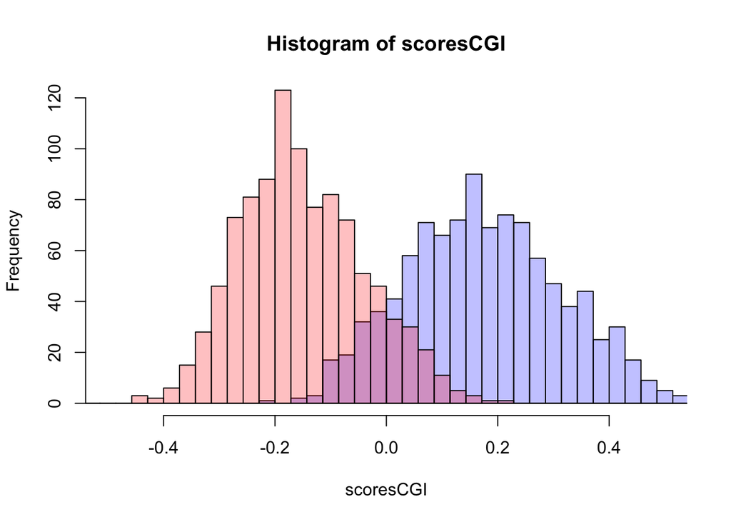

```r
generateRandomScores = function(s, len = 100, B = 1000) {
  alphFreq = alphabetFrequency(s)
  isGoodSeq = rowSums(alphFreq[, 5:ncol(alphFreq)]) == 0
  s = s[isGoodSeq]
  slen = sapply(s, length)
  prob = pmax(slen - len, 0)
  prob = prob / sum(prob)
  idx  = sample(length(s), B, replace = TRUE, prob = prob)
  ssmp = s[idx]
  start = sapply(ssmp, function(x) sample(length(x) - len, 1))
  scores = sapply(seq_len(B), function(i)
    scorefun(as.character(ssmp[[i]][start[i]+(1:len)]))
  )
  scores / len
}
scoresCGI    = generateRandomScores(seqCGI)
scoresNonCGI = generateRandomScores(seqNonCGI)

#make histogram
br = seq(-0.6, 0.8, length.out = 50)
h1 = hist(scoresCGI,    breaks = br, plot = FALSE)
h2 = hist(scoresNonCGI, breaks = br, plot = FALSE)
plot(h1, col = rgb(0, 0, 1, 1/4), xlim = c(-0.5, 0.5), ylim=c(0,120))
plot(h2, col = rgb(1, 0, 0, 1/4), add = TRUE)
```

We can consider these our training data: from data for which we know the types, we can see whether our score is useful for discriminating.

## Chapter Summary

**Goodness of fit**: We used different visualizations and showed how to run simulation experiments to test whether our data could be fit by a fair four box multinomial model. We encountered the chi-square statistic and saw how to compare simulation and theory using a qq-plot.

**Estimation** : We explained maximum likelihood and Bayesian estimation procedures. These approaches were illustrated on examples involving nucleotide pattern discovery and haplotype estimations.

**Prior and posterior distributions**: When assessing data of a type that has been been previously studied, such as haplotypes, it can be beneficial to compute the posterior distribution of the data. This enables us to incorporate uncertainty in the decision making, by way of a simple computation. **The choice of the prior has little effect on the result as long as there is sufficient data**.

**CpG islands and Markov chains**: We saw how dependencies along DNA sequences can be modeled by Markov chain transitions. We used this to build scores based on likelihood ratios that enable us to see whether long DNA sequences come from CpG islands or not. When we made the histogram of scores,it seemed to be made of two pieces. This bimodality was our first encounter with mixtures, they are the subject of Chapter 4.

## 2.13 Exercises

#### Exercise 2.1

Generate 1,000 random 0/1 variables that model mutations occurring along a 1,000 long gene sequence. These occur independently at a rate of 10^(-4) each. Then sum the 1,000 positions to count how many mutations in sequences of length 1,000.

```r
sim.seq <- rbinom(1000, 1, 0.0001)
sum(sim.seq)
```

```
## [1] 0
```

Find the correct distribution for these mutation sums using a goodness of fit test and make a plot to visualize the quality of the fit.

#### Exercise 2.2

Make a function that generates n random uniform numbers between 0 and 7 and returns their maximum. Execute the function for n=25. Repeat this procedure B=100 times. Plot the distribution of these maxima.

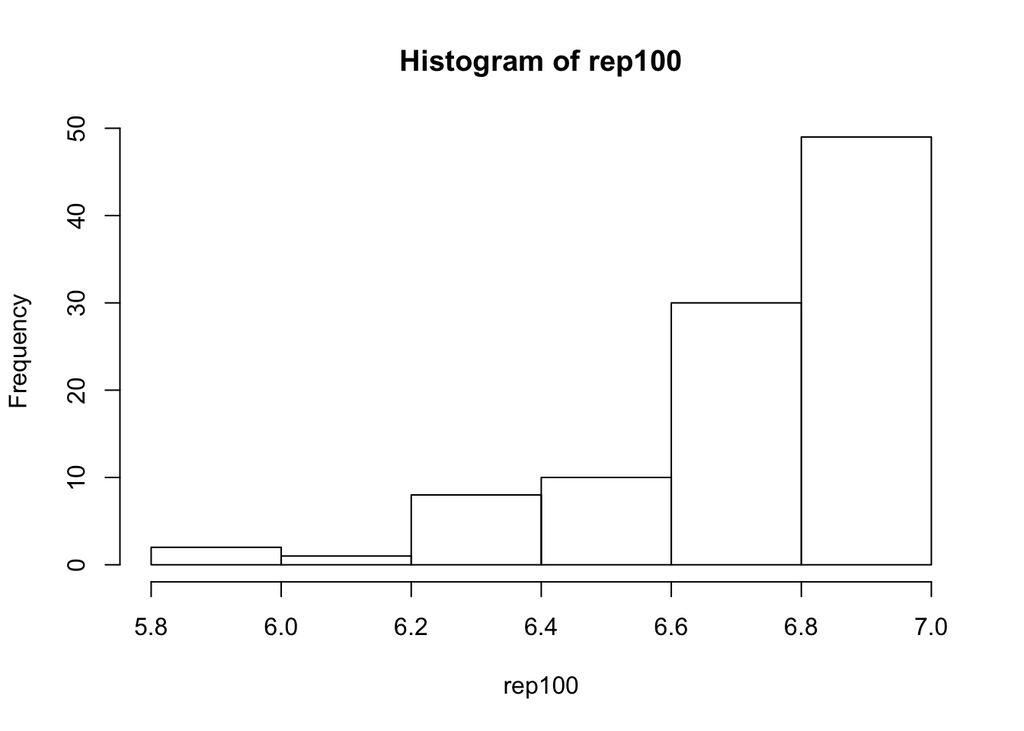

```r
notfun.fun <- function(n=10, min=0, max=1) {
sadnums <- runif(n, min, max)
maxsad <- max(sadnums)
maxsad
}
rep100 <- replicate(100, notfun.fun(25, 0, 7))
hist(rep100)
```

What is the maximum likelihood estimate of the maximum of a sample of size 25 (call it ^θ)?

```r
probs  =  seq(0, 7, length.out = 100)
likelihood = dbinom(sum(rep100), prob = probs, size = length(rep100))
```

[output not shown]

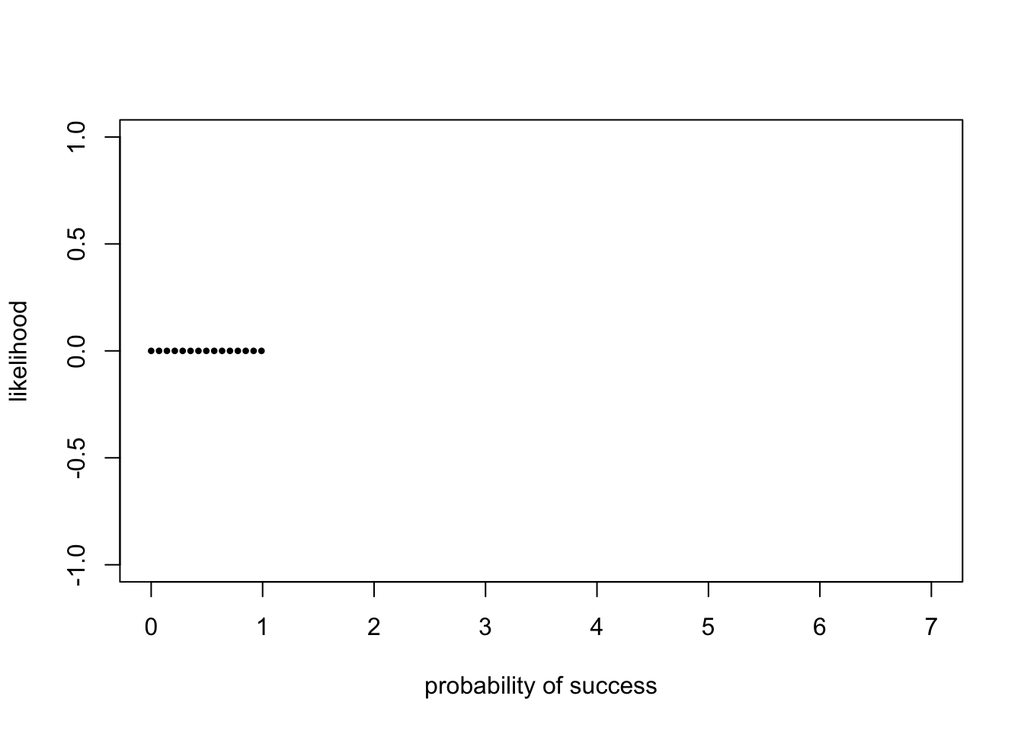

```r
plot(probs, likelihood, pch = 16, xlab = "probability of success",
       ylab = "likelihood", cex=0.6)
```

```r
probs[which.max(likelihood)]
```

```
## [1] 0
```

Can you find a theoretical justification and the true maximum θ?

#### Exercise 2.3

```r
mtb = read.table("M_tuberculosis.txt", header = TRUE)
head(mtb, n = 4)
```

```
##   AmAcid Codon Number PerThous
## 1    Gly   GGG  25874    19.25
## 2    Gly   GGA  13306     9.90
## 3    Gly   GGT  25320    18.84
## 4    Gly   GGC  68310    50.82
```

```r
pro  =  mtb[ mtb$AmAcid == "Pro", "Number"]
pro/sum(pro)
```

```
## [1] 0.54302025 0.10532985 0.05859765 0.29305225
```

1. Explore the data mtb using table to tabulate the AmAcid and Codon variables.

```r
table(mtb$AmAcid)
```

```
##
## Ala Arg Asn Asp Cys End Gln Glu Gly His Ile Leu Lys Met Phe Pro Ser Thr
##   4   6   2   2   2   3   2   2   4   2   3   6   2   1   2   4   6   4
## Trp Tyr Val
##   1   2   4
```

```r
table(mtb$Codon)
```

```
##
## AAA AAC AAG AAT ACA ACC ACG ACT AGA AGC AGG AGT ATA ATC ATG ATT CAA CAC
##   1   1   1   1   1   1   1   1   1   1   1   1   1   1   1   1   1   1
## CAG CAT CCA CCC CCG CCT CGA CGC CGG CGT CTA CTC CTG CTT GAA GAC GAG GAT
##   1   1   1   1   1   1   1   1   1   1   1   1   1   1   1   1   1   1
## GCA GCC GCG GCT GGA GGC GGG GGT GTA GTC GTG GTT TAA TAC TAG TAT TCA TCC
##   1   1   1   1   1   1   1   1   1   1   1   1   1   1   1   1   1   1
## TCG TCT TGA TGC TGG TGT TTA TTC TTG TTT
##   1   1   1   1   1   1   1   1   1   1
```

2. How was the PerThous variable created?
3. Write an R function that you can apply to the table to find which of the amino acids shows the strongest codon bias, i.e., the strongest departure from uniform distribution among its possible spellings.

#### Exercise 2.4

Display GC content in a running window along the sequence of Staphylococcus Aureus. Read in a fasta file sequence from a file.

```r
staph = readDNAStringSet("staphsequence.ffn.txt", "fasta")

#a) Look at the complete staph object and then display the first three sequences in the set.
staph
```

```
##   A DNAStringSet instance of length 2650
##        width seq                                       names
##    [1]  1362 ATGTCGGAAAAAGAAATTT...AGAAATAAGAAATGTATAA lcl|NC_002952.2_c...
##    [2]  1134 ATGATGGAATTCACTATTA...ACCAATCAGAACTTACTAA lcl|NC_002952.2_c...
##    [3]   246 GTGATTATTTTGGTTCAAG...TCATCAAGGTGAACAATGA lcl|NC_002952.2_c...
##    [4]  1113 ATGAAGTTAAATACACTCC...AGGTGAAATTATAAAGTAA lcl|NC_002952.2_c...
##    [5]  1932 GTGACTGCATTGTCAGATG...TGCAAACTTAGACTTCTAA lcl|NC_002952.2_c...
##    ...   ... ...
## [2646]   720 ATGACTGTAGAATGGTTAG...TCCTTTACTTGAAAAATAA lcl|NC_002952.2_c...
## [2647]  1878 GTGGTTCAAGAATATGATG...CCAAAGGGTGAGTGACTAA lcl|NC_002952.2_c...
## [2648]  1380 ATGGATTTAGATACAATTA...ATTCTGCTTAGGTAAATAG lcl|NC_002952.2_c...
## [2649]   348 TTGGAAAAAGCTTACCGAA...TAATAAAAAGATTAAGTAA lcl|NC_002952.2_c...
## [2650]   138 ATGGTAAAACGTACTTATC...TAAAGTTTTATCTGCATAA lcl|NC_002952.2_c...
```

```r
staph[1:3]
```

```
##   A DNAStringSet instance of length 3
##     width seq                                          names
## [1]  1362 ATGTCGGAAAAAGAAATTTGG...AAGAAATAAGAAATGTATAA lcl|NC_002952.2_c...
## [2]  1134 ATGATGGAATTCACTATTAAA...TACCAATCAGAACTTACTAA lcl|NC_002952.2_c...
## [3]   246 GTGATTATTTTGGTTCAAGAA...TTCATCAAGGTGAACAATGA lcl|NC_002952.2_c...
```

```r
#b) Find the GC content in tsequence windows of width 100.

#c) Display the GC content in a sliding window as a fraction.
```

4. How could we visualize the overall trends of these proportions along the sequence?

#### Exercise 2.5

Redo a figure similar to Figure 2.17, but include two other distributions: the uniform (which is B(1,1)) and the B(1/2,1/2). What do you notice?

[figure not shown]

```r
p = seq(1,1, length=100)
plot(p, dbeta(p, 1, 100), ylab="density", type ="l", col=4)
```

[figure not shown]

```r
q = seq(1/2,1/2, length=100)
plot(q, dbeta(q, 1, 100), ylab="density", type ="l", col=4)
```

There are constant?  
Am I doing this right?

#### Exercise 2.6

Choose your own prior for the parameters of the beta distribution. You can do this by sketching it here: https://jhubiostatistics.shinyapps.io/drawyourprior.  
Once you have set up a prior, re-analyse the data from Section 2.9.2, where we saw Y=40 successes out of n=300 trials. Compare your posterior distribution to the one we obtained in that section using a QQ-plot.

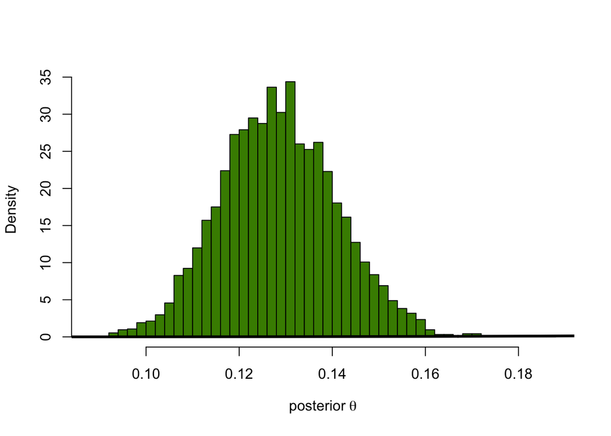

```r
thetaPostEmp = rtheta[ y == 40 ]
hist(thetaPostEmp, breaks = 40, col = "chartreuse4", main = "",
  probability = TRUE, xlab = expression("posterior"~theta))
densPostTheory  =  dbeta(thetas, 6.47, 5.64)
lines(thetas, densPostTheory, type="l", lwd = 3)
```

```r
thetaPostMC2 = rbeta(n = 1e6, 6.47, 5.64)
mean(thetaPostMC2)
```

```
## [1] 0.5341217
```

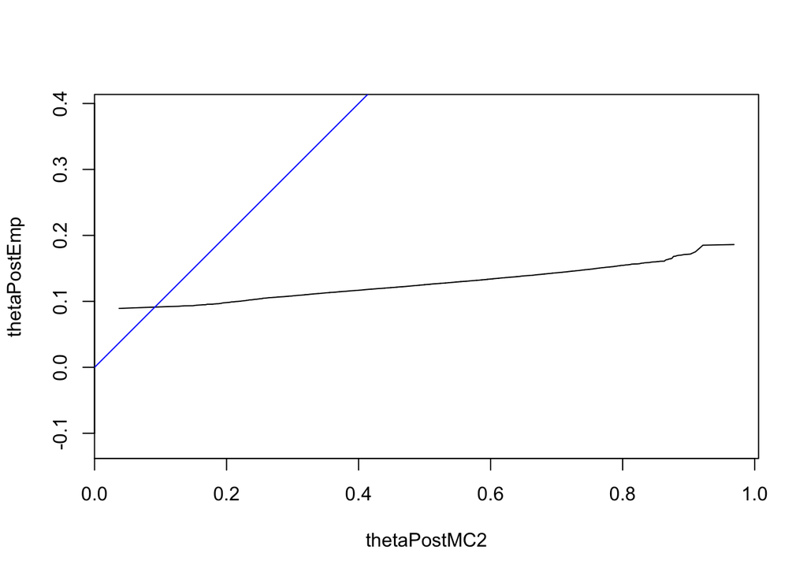

```r
qqplot(thetaPostMC2, thetaPostEmp, type = "l", asp = 1)
abline(a = 0, b = 1, col = "blue")
```

This looks weird?